# Lab 1

Samuel Pell

7/6/2022

Alter the below code chunks to complete the lab. Also, ensure you include your name in the `author` portion of this header. When finished, knit your file to an html and submit this to your TA for grading.

# 1 Initial Inspection

1. Include the `datasets` package. Then read in the `Seatbelts` dataset, and print the first five rows (0.5pt).
2. Check the dimension of the data, and find any missing observations (if they exist) (0.5pt).
3. Use the `as.data.frame` command to coerce the `Seatbelts` into a dataframe, and store it in a variable called `dat` (0.5pt).
4. Find the median of the `drivers` variable in `dat` (0.5pt).

```r
library(datasets)
data("Seatbelts")
head(Seatbelts, 5)
```

```
##      DriversKilled drivers front rear   kms PetrolPrice VanKilled law
## [1,]           107    1687   867  269  9059   0.1029718        12   0
## [2,]            97    1508   825  265  7685   0.1023630         6   0
## [3,]           102    1507   806  319  9963   0.1020625        12   0
## [4,]            87    1385   814  407 10955   0.1008733         8   0
## [5,]           119    1632   991  454 11823   0.1010197        10   0
```

```r
dim(Seatbelts)
```

```
## [1] 192   8
```

```r
any(is.na(Seatbelts))
```

```
## [1] FALSE
```

```r
dat <- as.data.frame(Seatbelts)

median(dat$drivers)
```

```
## [1] 1631
```

# 2 Visualization

1. Include the `tidyverse` library, and create a bar plot for the `VanKilled` variable within `dat`. Add color to the bars of this plot, and label the horizontal and vertical axes “VanKilled” and “Frequency” respectively (2pt).
2. Next create a scatterplot relating `DriversKilled` to `PetrolPrice` and coloring the points according to `VanKilled`. Remark as to why it might make sense that the trend appears to be negative (2pt).

```r
library(tidyverse)
```

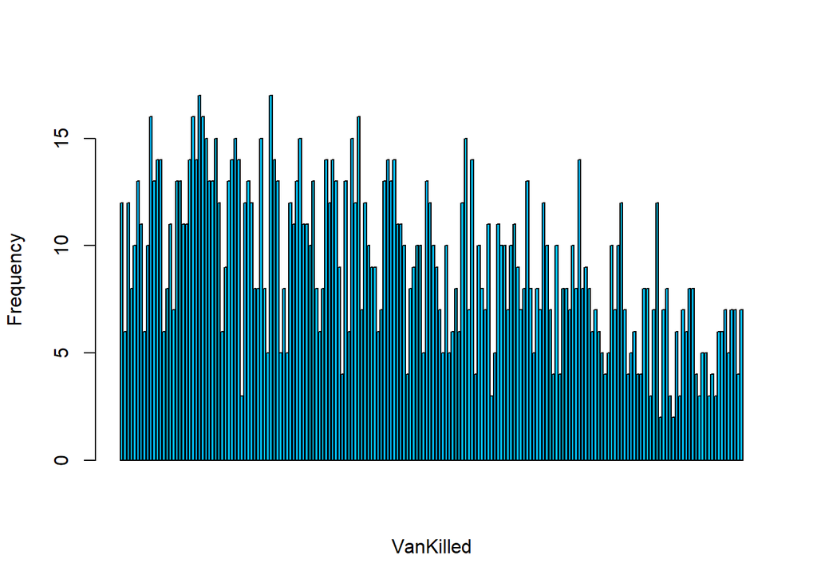

```r
barplot(dat$VanKilled, col = 'deepskyblue', xlab = 'VanKilled', ylab = 'Frequency')
```

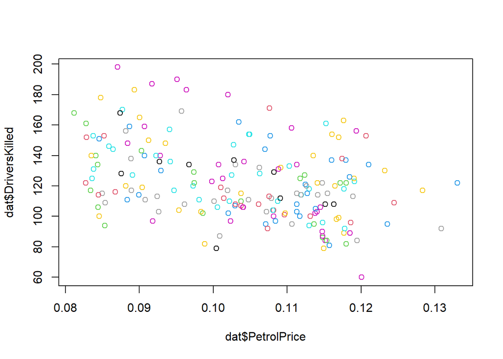

```r
plot(dat$DriversKilled~dat$PetrolPrice, col = dat$VanKilled)
```

```r
# The trend may be negative because the higher petrol prices prevent drivers from being killed indirectly, as they keep drivers off the road more and reduce the number of active drivers.
```

Next, we will pivot to the `volcano` dataset. This is a matrix reporting topographical information on the Maunga Whau Volcano. More specifically, entries report height of the volcano at specific points along the terrain. I have already included the necessary packages, and I have done some data wrangling (which we will learn about in the coming lectures) to make this data conformable to a heatmap.

1. *Before* I alter the data via wrangling, check the class, dimension, and type of the volcano matrix (2pt).
2. *After* the data has been manipulated, create a heatmap plotting X against Y and filling according to Z. Include horizontal and vertical axis labels as well as a title. In terms of X and Y coordinates, report the approximate position of the crater (spout) of the volcano (2pt).

```r
library(tidyr)
library(tibble)
library(hrbrthemes)
library(dplyr)

#student input
class(volcano)
```

```
## [1] "matrix" "array"
```

```r
dim(volcano)
```

```
## [1] 87 61
```

```r
typeof(volcano)
```

```
## [1] "double"
```

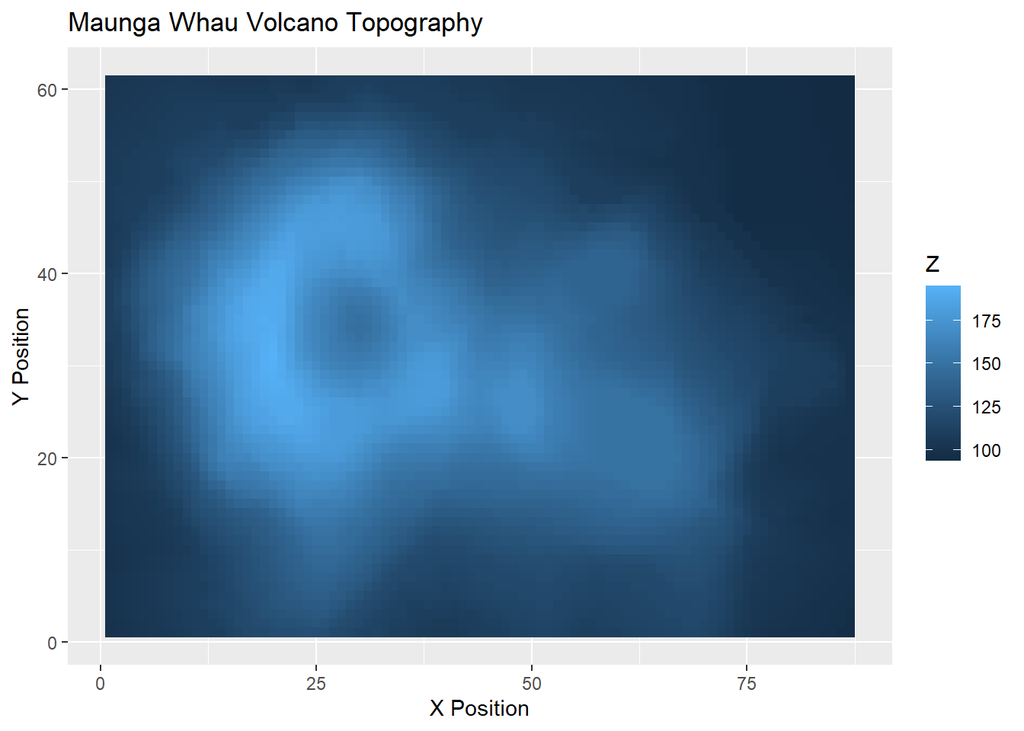

```r
# Heatmap
volcano %>%

  # Data wrangling
  as_tibble() %>%
  rowid_to_column(var="X") %>%
  gather(key="Y", value="Z", -1) %>%

  # Change Y to numeric
  mutate(Y=as.numeric(gsub("V","",Y))) %>%

#uncomment the above piping function before beginning ggplot command
#this will automatically pass in the altered volcano data.

#student input

  ggplot() +
    geom_tile(aes(x = X, y = Y, fill = Z)) +
    labs(x="X Position", y="Y Position", title="Maunga Whau Volcano Topography")
```

```r
# The X and Y coordinates of the spout are roughly x=30, y=35.
```